# Programming Techniques for Big Data

Georgios Gousios and Burcu Kulahcioglu Ozkan

17 September 2021

# Basic Data Types

In this section, we review the basic data types we use when processing data.

## Types of data

- **Unstructured**: Data whose format is not known
  - Raw text documents
  - HTML pages
- **Semi-Structured**: Data with a known format.
  - Pre-parsed data to standard formats: [JSON](https://api.github.com/events), [CSV](https://en.wikipedia.org/wiki/Comma-separated_values), [XML](http://www.ecb.europa.eu/stats/eurofxref/eurofxref-daily.xml)
- **Structured**: Data with known formats, linked together in graphs or tables
  - SQL or Graph databases
  - Images

**D**: *What types of data are more convenient when processing?*

## Sequences / Lists

**Sequences** or **Lists** or **Arrays** represent consecutive items in memory

In Python:

```python
a = [1, 2, 3, 4]
```

In Scala

```scala
val l = List(1, 2, 3, 4)
```

Basic properties:

- Size is bounded by memory
- Items can be accessed by an index: `a[1]` or `l(3)`
- Items can only be inserted at the end (*append*)
- Can be sorted

## Sets

Sets store values, without any particular order, and no repeated values.

```scala
scala> val s = Set(1, 2, 3, 4, 4)
s: scala.collection.immutable.Set[Int] = Set(1, 2, 3, 4)
```

Basic properties:

- Size is bounded by memory
- Can be queried for containment
- Set operations: union, intersection, difference, subset

## Maps or Dictionaries

**Maps** or **Dictionaries** or **Associative Arrays** is a collection of `(k,v)` pairs in such a way that each `k` appears only once.

Some languages have build-in support for Dictionaries

```python
a = {'a' : 1, 'b' : 2}
```

```scala
scala> val m = Map(("a", 1), ("b",2))
val m: scala.collection.immutable.Map[String,Int] = Map(a -> 1, b -> 2)
```

Basic properties:

- One key always corresponds to one value.
- Accessing a value given a key is very fast ($\approx O(1)$)

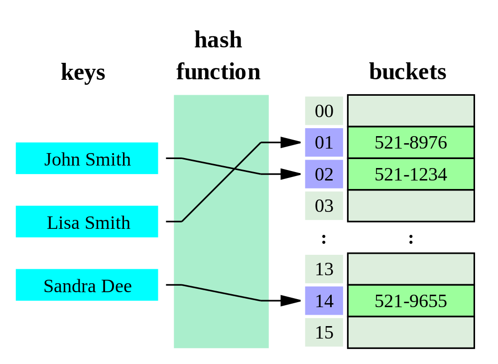

A HashTable

## Nested data types: Graphs

A graph data structure consists of a finite set of vertices or nodes, together with a set of unordered pairs of these vertices for an undirected graph or a set of ordered pairs for a directed graph.

- Nodes can contain attributes
- Edges can contain weights and directions

Graphs are usually represented as `Map[Node, List[Edge]]`, where

```scala
case class Node(id: Int, attributes: Map[A, B])
case class Edge(a: Node, b: Node, directed: Option[Boolean],
                  weight: Option[Double] )
```

## Nested data types: Trees

Ordered graphs without loops

```python
a = {"id": "5542101946", "type": "PushEvent",
    "actor": {
      "id": 801183,
      "login": "tvansteenburgh"
    },
    "repo": {
      "id": 42362423,
      "name": "juju-solutions/review-queue"
   }}
```

If we parse the above JSON in almost any language, we get a series of nested maps

```scala
Map("id" -> 5542101946L,
    "type" -> "PushEvent",
    "actor" -> Map("id" -> 801183.0, "login" -> "tvansteenburgh"),
    "repo" -> Map("id" -> 4.2362423E7, "name" -> "juju-solutions/review-queue"))
)
```

## Tuples

An $n$-tuple is a sequence of $n$ elements, whose types are known.

```scala
val record = Tuple4[Int, String, String, Int] (1, "Matt", "Damon", 1970)
// alternatively
val record = (1, "Matt", "Damon", 1970)
```

Scala makes it easy to declare and use tuples by automatically inferring the types of the tuple contents.

```scala
val a = (1, ("Foo", 2)) // type: Tuple2[Int, Tuple2[String, Int]]
// alternatively: (Int, (String, Int))

println(a._1) // prints 1
println(a._2._1) // prints Foo
```

## Relations

A *relation* is a `Set` of $n$-tuples $(d1, d2, ..., dn)$ of the same type; one of the tuple elements denotes a *key*. Keys cannot be repeated.

Relations are very important for data processing, as they form the theoretical framework ([Relational Algebra](https://en.wikipedia.org/wiki/Relational_algebra)) for *relational (SQL) databases*.

Typical operations on relations are insert, remove and *join*. Join allows us to compute new relations by joining existing ones on common fields.

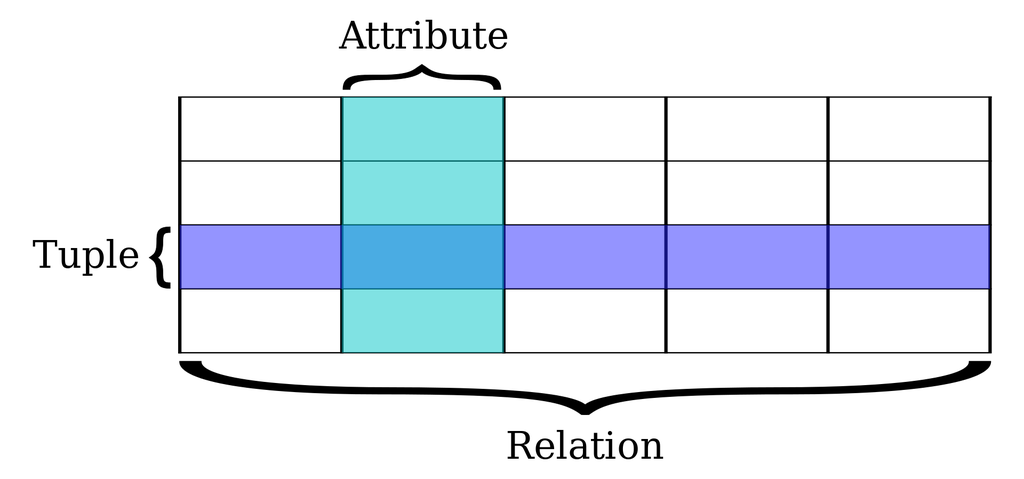

Relations

## Relations example

```scala
val movie1 = (1, "Martian", "PG-13", 2015, 2)
val movie2 = (2, "Prometheus", "R", 2012, 2)
val movie3 = (3, "2001: Space Odyssey", "G", 1968, 1)

val movies = Set(movie1, movie2, movie3)

val stanley = (1, "Stanley Kubrick", 1928)
val ridley = (2, "Ridley Scott", 1937)

val directors = Set(stanley, ridley)
```

**Q:** How can we get a list of directors and the movies of each director?

## Key/Value pairs

A key/value pair (or K/V) is a more general type of a relation, where each key can appear more than once.

```scala
// We assume that the first Tuple element represents the key
val a = (1, ("Martian", 2015))
val b = (1, ("Prometheus", 2012))

val kv = List(a, b)
// type: List[(Int, (String, Int))]
```

Another way to represent K/V pairs is with a `Map`

```scala
val xs = Map(1 -> List(("Martian", 2015), ("Prometheus", 2012)))
// type: Map[Int, List[(String, Int)]]
```

K and V are flexible: that’s why the Key/Value abstraction is key to NoSQL databases, including MongoDB, DynamoDB, Redis etc.

# Functional Programming in a Nutshell

In this section, we discuss the basics of functional programming, as those apply to data processing with tools like Hadoop, Spark and Flink.

## Functional programming

Functional programming is a programming paradigm where programs are constructed by applying and composing functions. (Wikipedia).

Functional programming characteristics:

- Absence of **side-effects**: A function, given an argument, always returns the same results irrespective of and without modifying its environment.
- **Immutable** data structures: Side-effect free functions operate on immutable data.
- **Higher-order functions**: Functions can take functions as arguments to parametrize their behavior
- **Laziness**: The art of waiting to compute till you can wait no more

## Function signatures

$foo(x: [A], y: B) \rightarrow C$

- $foo$: function name
- $x$ and $y$: Names of function arguments
- $[A]$ and $B$: Types of function arguments.
- $\rightarrow$: Denotes the return type
- $C$: Type of the returned result
- $[A]$: Denotes that type $A$ can be traversed

We read this as: *Function foo takes as arguments an array/list of type A and an argument of type B and returns an argument of type C*

**Q**: *What does the following function signature mean?* $f(x:[A], y:(z: A) \rightarrow B) \rightarrow [B]$

## Side effects

A function has a side effect if it **modifies** some state outside its scope or has an observable interaction with its calling functions or the outside world besides returning a value.

```scala
var max = -1

def greaterOrEqual(a: Int, b: Int): Boolean = {
  if(a >= b) {
      max = a // side effect!
      true
    } else {
      max = b // side effect!
      false
    }
}
```

As a general rule, any function that returns nothing (`void` or `Unit`) does a side effect!

### Pure functions

A **[pure function](https://docs.scala-lang.org/overviews/scala-book/pure-functions.html)** depends only on its declared inputs and its internal algorithm to produce its output.

- It does not read any other values
- It does not have any side effects

```scala
def greaterOrEqual(a: Int, b: Int, max: Int): (Boolean, Int) = {
  if(a >= b) (true, a)
  else (false, b)
}
```

Pure functions offer **referential transparency**.

### Referential transparency

An expression is said to be **referentially transparent** if it can be replaced by its value and not change the program’s behavior.

Referential transparency enables simpler reasoning about programs.

```scala
var base = 10

def plus(a: Int): Int = {
  base + a
}
```

Q: Is this function *referentially transparent*?

### Examples of side effects

- Modifying a variable
- Modifying a data structure in place: In FP, data structures are always [persistent](https://en.wikipedia.org/wiki/Persistent_data_structure).
- Setting a field on an object: OO is not FP!
- Throwing an exception or halting with an error: In FP, we use types that encapsulate and propagate erroneous behavior
- Printing to the console or reading user input, reading writing to files or the screen: In FP, we encapsulate external resources into *Monads*.

How can we write code that does something useful given those restrictions?

## From OO to FP

### Buying coffee in OO

```scala
class Cafe {
  def buyCoffee(cc: CreditCard): Coffee = {
    val cup = new Coffee()
    cc.charge(cup.price)
    cup
  }
}
```

Can you spot any problems with this code?

- `charge()` performs a side-effect: we need to contact the credit card company!
- `buyCoffee()` is *not testable*

### Breaking external dependencies

```scala
class Cafe {
  def buyCoffee(cc: CreditCard, p: Payments): Coffee = {
    val cup = new Coffee()
    p.charge(cc, cup.price)
    cup
  }
}
```

Slightly better option, *but*:

- `Payments` has to be an interface
- We still need to perform side effects
- We need to inspect state within the `Payments` mock

**Q:** How can we buy 10 coffees?

### Buying 10 coffees

```scala
class Cafe {
  def buyCoffee(cc: CreditCard, p: Payments): Coffee = { ... }

  def buyCoffees(cc: CreditCard, p: Payments, num: Int) = {
    for (i <- 1 to num) {
      buyCoffee(cc, p)
    }
  }
}
```

Seems to be working, *but*:

- No way to batch payments
- No way to batch checkouts

### Removing side effects

**Idea**: How about instead of charging in place, we decouple the action of *buying* coffee from that of *charging* for it?

```scala
class Cafe {
  def buyCoffee(cc: CreditCard): (Coffee, Charge) = {
    val cup = new Coffee()
    (cup, Charge(cc, cup.price))
  }
}

class Charge(cc: CreditCard, amount: Double) {
  def combine(other: Charge) = new Charge(cc, amount + other.amount)
  def pay = cc.charge(amount)
}
```

Nice! We can now:

- Test
- Combine multiple `Charge`s in one
- Maintain in flight accounts for all customers

### Buying 10 functional coffees

```scala
class Charge(cc: CreditCard, amount: Double) {
  def combine(other: Charge) = new Charge(cc, amount + other.amount)
  def pay = cc.charge(amount)
}

class Cafe {
  def buyCoffee(cc: CreditCard): (Coffee, Charge) = { ...   }
  def buyCoffees(cc: CreditCard, num: Int): Seq[(Coffee, Charge)] =
    (1 to num).map(buyCoffee(cc))

  def checkout(cc: CreditCard, charges: Seq[Charge]) : Seq[Charge] = {
    charges
      .filter(charge => charge.cc == cc)
      .foldLeft(new Charge(cc, 0.0)){(acc, x) => acc.combine(x)}
      .pay  // <- side-effect, but once, in one place.

    charges.filter(charge => charge.cc != cc)
  }
}
```

*This example was adapted from the (awesome) [FP in Scala](https://www.manning.com/books/functional-programming-in-scala) book, by Chiusano and Bjarnason*

## Immutable data structures

Functional data structures are operated on pure functions and they are immutable.

Scala has immutable lists, tuples, maps, and sets.

```scala
  val oneTwoThree = List(1, 2, 3)
  val oneTwoThree_2 = 1 :: 2 :: 3 :: Nil
  val one = oneTwoThree.head
  val twoThree = oneTwoThree.tail
```

*Scala has both mutable and immutable versions of many common data structures. If in doubt, use immutable.*

### Pattern matching on data structures

“Pattern matching” checks a value against a pattern.

It can deconstruct a value into its constituent parts if the match is successful.

```scala
  def length(ints: List[Int]): Int = ints match {
    case Nil => 0
    case x :: xs => 1 + length(xs)
  }
```

Q: What is the result of the following expression?

```scala
  val x = List(1,2,3,4,5) match {
    case x :: 2 :: 4 :: xs => x
    case Nil => 42
    case x :: y :: 3 :: 4 :: xs => x + y
    case h :: t => h
    case _ => 404
  }
```

### Recursion on data structures

```scala
  def incrementAll(ints: List[Int]): List[Int] = ints match {
    case Nil => Nil
    case x :: xs => x + 1 :: incrementAll(xs)
  }
```

```scala
  def doubleAll(ints: List[Int]): List[Int] = ints match {
    case Nil => Nil
    case x :: xs => x * 2 :: doubleAll(xs)
  }
```

We can generalize the pattern using a **higher-order function**.

## Higher-order functions

A higher-order function is a function that can take a function as an argument or return a function.

```scala
  // Return elements that satisfy f
  def filter(xs: List[A], f: A => Boolean) : List[A]
```

In the context of BDP, high-order functions capture common idioms of processing data as enumerated elements, e.g. going over all elements, selectively removing elements and aggregating them.

### Defining and using higher-order functions

Defining a higher order function, `applyToAll`:

```scala
  def applyToAll[A, B](xs: List[A], f: A => B): List[B] = xs match {
    case Nil => Nil
    case h :: t => f(h) :: applyToAll(t, f)
  }
```

Using `applyToAll` to define other functions:

```scala
  def incrementAll2(ints: List[Int]): List[Int] = applyToAll(ints, (x:Int) => x + 1)
  def doubleAll2(ints: List[Int]): List[Int] = applyToAll(ints, (x:Int) => x * 2)
```

Scala collections has built-in `map` function:

```scala
  def incrementAll3(ints: List[Int]): List[Int] = ints.map((x:Int) => x + 1)
  def doubleAll3(ints: List[Int]): List[Int] = ints.map((x:Int) => x * 2)
```

### Important higher-order functions

**`map(xs: List[A], f: A => B) : List[B]`**

Applies `f` to all elements and returns a new list.

**`flatMap(xs: List[A], f: A => List[B]) : List[B]`**

Like `map`, but flattens the result to a single list.

**`foldL(xs: List[A], f: (B, A) => B, init: B) : B`**

Takes `f` of 2 arguments and an init value and combines the elements by applying `f` on the result of each previous application. AKA `reduce`.

### Aux higher-order functions

**`groupBy(xs: List[A], f: A => K): Map[K, List[A]]`**

Partitions `xs` into a map of traversable collections according to a discriminator function.

**`filter(xs: List[A], f: A => Boolean) : List[A]`**

Takes a predicate and returns all elements that satisfy it

**`scanL(xs: List[A], f: (B, A) => B, init: B) : List[B]`**

Like `foldL`, but returns a list of all intermediate results

**`zip(xs: List[A], ys: List[B]): List[(A,B)]`**

Returns an iterable collection formed by iterating over the corresponding items of `xs` and `ys`.

## Laziness

*Laziness* is an evaluation strategy which delays the evaluation of an expression until its value is needed.

- Separating a pipeline construction from its evaluation
- Not requiring to read datasets in memory: we can process them in lazy-loaded batches
- Generating *infinite* collections
- Optimizing execution plans

```scala
def fibs: LazyList[Int] = {
  0 #:: 1 #:: fibs.zip(fibs.tail).map{ n =>
    println("Adding " + n._1 + " and " + n._2)
    n._1 + n._2
  }
}
fibs.take(5).foreach(println)
```

```python
def fib(limit):
    x = 0
    y = 1
    yield x
    yield y
    for i in range(3, limit+1):
        print("Adding " + str(x) + " and " + str(y))
        x, y = y, x + y
        yield y


for i in fib(5):
    print(i)
```

```
## 0
## 1
## Adding 0 and 1
## 1
## Adding 1 and 1
## 2
## Adding 1 and 2
## 3
```

### Laziness: Another example

```python
def primes(limit):
    sieve = [False] * limit

    for j in range(2, limit):
        print("Before yield: " + str(j))
        if sieve[j]: continue
        yield j
        print("After yield: " + str(j))
        if j*j > limit: continue
        for i in range(j, limit, j):
            sieve[i] = True

for x in primes(5):
    print(x)
```

```
## Before yield: 2
## 2
## After yield: 2
## Before yield: 3
## 3
## After yield: 3
## Before yield: 4
```

### Lazy data pipelines

In tools like Spark and Flink, we always express computations in a lazy manner. This allows for optimizations before the actual computation is executed

```python
# Word count in PySpark
text_file = sc.textFile("words.txt")
counts = text_file \
              .flatMap(lambda line: line.split(" ")) \
              .map(lambda word: (word, 1)) \
              .reduceByKey(lambda a, b: a + b)

counts.saveAsTextFile("results.txt")
```

**Q:** In the code above, when will Spark compute the result?

**A:** When `saveAsTextFile` is called!

## Monads

*Monads* are a design pattern that defines how functions can be used together to build generic types.

Practically, a monad is a value-wrapping type that:  
* Has an `identity` function * Has a `flatMap` function, that allows data to be transferred between monad types

```scala
trait Monad[M[_]] {
  def unit[S](a: S) : M[S]
  def flatMap[S, T] (m: M[S])(f: S => M[T]) : M[T]
}
```

Monads are the tool FP uses to deal with (side-)effects

- Null points: `Option[T]`
- Exceptions: `Try[T]`
- Latency in asynchronous actions: `Future[T]`

### Tackling the effect of throwing exceptions

Exceptions break referential transparency.

```scala
def failingFn(i: Int): Int = {
  val x: Int = throw new Exception("fail!")
  try {
    x + 1
  } catch { case e: Exception => -1 }
}
```

Exceptions are not type-safe and lead to complicated control-flow.

```scala
def mean(xs: Seq[Double]): Double =
  if (xs.isEmpty)
  throw new ArithmeticException("mean of empty list!")
  else xs.sum / xs.length
```

**Q**: How to handle exceptions?

### Solution attempt: Return a predefined bogus value

```scala
def mean(xs: Seq[Double]): Double =
  if (xs.isEmpty) return 0
  else xs.sum / xs.length
```

- Allows errors to silently propagate
- Not applicable to polymorphic code
- Difficult to use the result – requires special policy

### Solution: Mapping effects to the type system

`Option` wraps a value that may be null or undefined. `Option[A]` can have 2 instances: * `Some[A]`, where A represents the type of the value  
* `None`, if the value is undefined

```scala
def mean(xs: Seq[Double]): Option[Double] =
  if (xs.isEmpty) None
  else Some(xs.sum / xs.length)
```

### Combining monads with `flatMap`

`flatMap` enables us to join sequences of arbitrary types.

- Example: Combining `Option`s that wrap undefined values

```scala
def getArgument(k: String): Option[Arg]
def processArgument(a: Arg): Option[Result]

getArgument("foo")
  .flatMap(processArgument)
  .getOrElse(new Result("default"))
```

- Example: Combining `Future`s that wrap values that will be eventually available

```scala
def callWebService(): Future[R]
def heavyComputation(r: R): Future[V]

val r = callWebService().flatMap(r => heavyComputation2(r))
```

### Dealing with exceptions: Scala

`Try` wraps a computation that may either result in an exception, or return a successfully computed value.  
`Try` is a type that can have 2 instances:

- `Success[T]`, where `T` represents the type of the result
- `Failure[E]`, where `E` represents the type of error, usually an exception

```scala
object Converter extends App {
  def toInt(a: String): Try[Int] = Try{Integer.parseInt(a)}
  def toString(b: Int): Try[String] = Try{b.toString}

  val a = toInt("4").flatMap(x => toString(x))
  println(a)

  val b = toInt("foo").flatMap(x => toString(x))
  println(b)
}
```

```
## Success(4)
## Failure(java.lang.NumberFormatException: For input string: "foo")
```

### Dealing with exceptions: Java

```java
public class Converter {
  public static Integer toInt(String a) throws NumberFormatException {
    return Integer.parseInt(a);
  }

  public static String toString(Integer a) throws NullPointerException {
    return a.toString();
  }

  public static void main(String[] args) {
    try {
      Integer five = toInt("5");
      try {
        String str = toString(five);
      } catch(NullPointerException e) {
        //baaah
      }
    } catch(NumberFormatException r) {
        //ooofff
    }
  }
}
```

### Another example: Mapping effects to the type system

```scala
object Amazon {
  def login(login: String, passwd: String): Future[Amazon]
}

class Amazon(val user: String) {
  def search(term: String): Future[Seq[String]]
}

object Main extends App {
  val result = Amazon.login("uname", "passwd") // Might fail
      .flatMap(a => a.search("foo"))
  val resultVal = result.value
  }
}
```

**Q:** What would be the type of `result`?  
**Q:** What would be the type of `resultVal`?

- `Future[Seq[String]]`
- `Try[Seq[String]`
- `Option[Try[Seq[String]]]`

# Enumerating datasets

Before starting to process datasets, we need to be able to go over their contents in a systematic way. The process of visiting all items in a dataset is called *traversal*.

## Big data sets

In a big data system:

- **Client** code processes data
- A **data source** is a container of data (e.g. array, database, web service)

There are two fundamental techniques for the client to process all available data in the data source

- **Iteration**: The client *asks* the data source whether there are items left and then *pulls* the next item.
- **Observation**: The data source *pushes* the next available item to a client end point.

**D**: *What are the relative merits of each technique?*

## Iteration

In the context of BDP, iteration allows us to process finite-sized data sets without loading them in memory at once.

```scala
trait Iterator[A] {
  def hasNext: Boolean
  def next(): A
}
```

Typical usage

```scala
val it = Array(1,2,3,4).iterator
while(it.hasNext) {
  val i = it.next + 1
  println(i)
}
```

The `Iterator` pattern is supported in all programming languages.

## Iteration example

Reading from a file, first in Scala

```scala
val data = scala.io.Source.fromFile("/big/data").getLines
while (data.hasNext) {
  println(data.next)
}
// Equivalently...
for (line <- data) {
  println(line)
}
```

and then in Python

```python
with open("/big/data","r") as data:
  # readlines() returns an object that implements __iter__()
  for line in data.readlines():
      print line
```

## Observation

Observation allows us to process (almost) unbounded size data sets, where the data source controls the processing rate

```scala
// Consumer
trait Observer[A] {
  def onNext(a: A): Unit
  def onError(t: Throwable): Unit
  def onComplete(): Unit
}

// Producer
trait Observable[A] {
  def subscribe(obs: Observer[A]): Unit
}
```

Example usage

```scala
  // Example using library rx.lang.scala
  // Having additional method in Observable: def subscribe(onNext: T => Unit)
  Observable.just(1, 2 ,3 ,4 ,5)
    .map(x => x + 1)
    .subscribe(x => println(x))
```

## Iteration and Observation

- Iteration and Observation are *dual*
- The same set of higher-order functions can be used to process data in both cases

Iterator-based `map`. “Pulls” data out of array.

```scala
Array(1,2,3,4).map(x => x + 1) // Scala
```

```python
map([1,2,3,4], lambda x: x + 1) # Python
```

Observation-based (reactive) `map`. Data is “pushed” to it asynchronously, when new data is available.

```scala
Observable.just(1,2,3,4,5).map(x => x + 1) // Scala with rx.lang.scala
```

```python
Observable.from_([1,2,3,4]).map(lambda x: x + 1) # Python
```

**D:** (How) Can we convert between the two types of enumeration?

## Traversal

We apply a strategy to visit all individual items in a collection.

```scala
  val l = List(1, 2, 3)
  l.foreach(print)

  val m = Map("x" -> 1, "y" -> 2)
  m.foreach(print)
```

In case of nested data types (e.g. trees/graphs), we need to decide how to traverse. Common strategies include:

- **Breadth-first traversal**: From any node A, visit its neighbors first, then its children.
- **Depth-first traversal**: From any node A, visit its children first, then its neighbors.

## Traversal through iteration

In most programming environments, traversal is implemented by *iterators*.

```scala
  case class Tree(value: String, children: List[Tree])

  def dfs(tree: Tree): Iterator[String] = tree match {
    case Tree(value, Nil) => Iterator(value)
    case Tree(value, children) => children.iterator.flatMap(c => dfs(c)) ++ Iterator(value)
  }
```

Then, we can iterate using standard language constructs.

```scala
  val tree = Tree("a", List(Tree("b", List(Tree("c", Nil), Tree("d", Nil)))))
  dfs(tree).foreach(print)
```

# Operations

Operations are transformations, aggregations or cross-referenceing of data stored in data types. All of container data types can be iterated.

We generally have two types of operations:

- **Element-wise** ops apply a function to each individual message (e.g. map or flatMap).
- **Aggregations** group multiple events together and apply a reduction (e.g. fold or max) on them.

## Element-wise operations

- **Conversion**: Convert values of type $A$ to type $B$
  - Celcius to Kelvin
  - € to $
- **Filtering**: Only present data items that match a condition
  - All adults from a list of people
  - Remove duplicates
- **Projection**: Only present parts of each data item
  - From a list of cars, only display their brand

### Our running example

Suppose we have a list of people; each person is identified by a unique identifier, their age, their height in cm and their gender.

```scala
case class Person(id: Int, age: Int, height: Double, weight: Int, gender: String)
```

Now, let’s create 1000 random people!

```scala
  val genders = List("Male", "Female", "Other")
  val rand = new Random(42)

  val people = (1 to 1000).map(i => Person(i,
    age = rand.between(10, 80),
    height = rand.between(60, 200),
    weight = rand.between(40, 120),
    gender = genders(rand.between(0, 3))))
    .toList
```

[output not shown]

### Conversion or Mapping

To convert values, we traverse a collection and apply a conversion function to each individual element. This is generalized to the $map$ function:

$map(xs: [A], f: (A) \rightarrow B) \rightarrow [B]$

Let’s convert the persons’ heights to meters

```scala
  def toMeters(person: Person): Person = person.copy(height = person.height * 1.0 / 100)

  val peopleInMeters = map(people, p => toMeters(p))
```

or using a lambda function:

```scala
  val peopleInMeters = map(people, p => p.copy(height = p.height * 1.0 / 100))
```

Note: [Scala `List`](https://www.scala-lang.org/api/2.13.3/scala/collection/immutable/List.html) has built-in implementations for most of the functions we discuss in this lecture.

```scala
  // definition in scala.collection.immutable.List
  def map[B](f: (A) => B): List[B]
```

```scala
  // example usage of the built-in function
  val peopleInMeters = people.map(p => p.copy(height = p.height * 1.0 / 100))
```

### Projection

Projection allows us to select parts of a Tuple, Relation or other nested data type for further processing. To implement this, we need to iterate over all items of a collection and apply a *conversion* function.

```scala
  val heightsAndWeights = map(people, (p: Person) => (p.height, p.weight))
  val weights = map(people, (p:Person) => p.weight)
```

### Filtering

To filter values from a list, we traverse a collection and apply a predicate function to each individual element.

$filter(xs: [A], f: (A) \rightarrow Boolean): [A]$

```scala
val tallPeople = filter(people, p => p.height > 180)
```

**Q:** How can we implement filter?

```scala
  def filter(xs: List[Person], pred: Person => Boolean): List[Person] = xs match {
    case Nil => Nil
    case h :: t if pred(h) => h :: filter(t, pred)
    case h :: t => filter(t, pred)
  }
```

Filter on a generic class:

```scala
  def filter[T](xs: List[T], pred: T => Boolean): List[T] = xs match {
    case Nil => Nil
    case h :: t if pred(h) => h :: filter(t, pred)
    case h :: t => filter(t, pred)
  }
```

## Aggregations

Aggregations apply a *combining operator* on a traversable sequence to aggregate the individual items into a single result.

Aggregation is implemented using reduction or folding. Two variants exist: *left reduction (or folding)* and *right reduction (or folding)*.

- With left reduction/folding, we traverse items from the first to last
- With right reduction/folding, we traverse items from the last to first

### Example: Calculate total weight

Our task is to calculate the total weight for our people list. To do so, we need to iterate over the list and add the individual weights. First, we do it with an imperative approach:

```scala
  var totalWeight = 0

  weights.foreach(w => {
    totalWeight = totalWeight + w
  })

  println(totalWeight)
```

We notice that iteration and reduction are independent. What if we abstract iteration away?

### Folding left

Folding functions generate a single value from a collection of data.

$foldLeft(xs: [A], init: B, f: (acc: B, x: A) \rightarrow B) \rightarrow B$

Left fold takes a function `f` with 2 arguments and an initial value and applies `f` on all items, starting from the **left** most. `f` combines the result of its previous application with the current element.

```scala
  def totalWeight(acc: Double, p: Person): Double = // acc is for accumulator
    acc + p.weight
```

Then we can calculate the total weight of all people in our collection as follows

```scala
val total = foldLeft(people, 0, (acc: Double, p: Person) => totalWeight(acc, p))
// or equivalently
val total = foldLeft(people, 0, (acc: Double, p: Person) => acc + p.weight)
```

### Folding right

$foldRight(xs: [A], init: B, f: (x: A, acc: B) \rightarrow B) \rightarrow B$

Right fold takes a function `f` with 2 arguments and an initial value and applies `f` on all items, starting from the **right** most. `f` combines the result of its previous application with the current element.

```scala
val total = foldRight(people, 0, (p: Person, acc: Double) => (p.weight + acc))
```

### `foldRight` and `foldLeft`: differences

To see how `foldRight` and `foldLeft` are evaluated, we define a reduction function that accumulates the intermediate steps as a string.

```scala
def reduce_str(acc: String, x: String): String = "(" + acc + " + " + x + ")"
```

How does `foldLeft` work?

```scala
println(foldLeft(List(1,2,3,4,5).map(_.toString), "0", reduce_str))
```

```
## (((((0 + 1) + 2) + 3) + 4) + 5)
```

How does `foldRight` work?

```python
println(foldRight(List(1,2,3,4,5).map(_.toString), "0", reduce_str))
```

```
## (1 + (2 + (3 + (4 + (5 + 0)))))
```

**Q**: *Can we always apply `foldLeft` instead of `foldRight`?*

### `foldRight` != `foldLeft`

The answer to the previous question is: *it depends on whether the reduction operation is commutative*.

An op $\circ$ is commutative iff $x \circ y = y \circ x$.

We can see that if we choose a non-commutative operator, `reduceL` and `reduceR` produce different results.

```scala
val resultLeft = foldLeft(List(1,2,3,4,5), 0, (x:Int, y:Int) => x - y)

val resultRight = foldRight(List(1,2,3,4,5), 0, (x:Int, y:Int) => x - y)
```

Q: What are the values of `resultLeft` and `resultRight`?

### `reduceRight` and `reduceLeft`

Similar to `foldRight` and `foldLeft`, reduce functions generate a single value from a list of sequence starting from *right* or *left*.

Therefore, `reduceRight` != `reduceLeft`

```scala
val weights = people.map(_.weight)
val totalWeightLeft = weights.reduceLeft(_ + _)
val totalWeightRight = weights.reduceRight(_ + _)
```

## Counting elements

The simplest possible aggregation is counting the number of elements, possibly matching a condition

$count(xs: [A], pred): Integer$

```scala
def count(list: List[Int], f: Int => Boolean) =  filter(list,f).length
```

**Q:** How can we implement this with folding?

## Distinct elements

Given a sequence of items, produce a new sequence with no duplicates.

$distinct(xs: [A]): [A]$

```scala
val a = List(1,2,2,3)
a.distinct
a.toSet
```

```
## List(1, 2, 3)
## Set(1, 2, 3)
```

Distinct assumes that items have unique identities; in Python, we use the `id()` method (same as `hashCode()` in Java).

## Numerical aggregations

Aggregation functions have the following generic signature:

$f: [A] \rightarrow Number$

Their job is to reduce sequences of elements to a single measurement. Some examples are:

- Mathematical functions: `min`, `max`, `count`
- Statistical functions: `mean`, `median`, `stdev`

## Grouping

Grouping splits a sequence of items to groups given a classification function.

$groupBy(xs:[A], f: A \rightarrow K): Map[K, [A]]$

```scala
  def groupBy(xs: List[Int], classifier: Int => String): Map[String, List[Int]] = {
    groupByHelper(xs, classifier, Map())
  }

  private def groupByHelper(xs: List[Int], classifier: Int => String, groups: Map[String, List[Int]]): Map[String, List[Int]] = xs match {
    case Nil => groups
    case h :: t =>
      val key: String = classifier(h)
      val value: List[Int] = h :: groups.getOrElse(key, List[Int]())
      groupByHelper(t, classifier, groups + ((key,  value)))
  }
```

```scala
def number_classifier(x: Int): String =
  if (x % 2 == 0) "even"
  else "odd"

val list = List(1, 2, 3, 4, 5, 6, 7)
print(groupBy(list, number_classifier))
```

```
## Map(odd -> List(7, 5, 3, 1), even -> List(6, 4, 2))
```

## Aggregation example

How can we get the average height per gender (adults only) in our list of people?

```scala
  val adults = people.filter(_.age > 18)
  val adultsByGender = adults.groupBy(_.gender)
  val heightsByGender = adultsByGender.map(x => (x._1, x._2.map(_.height)))
  val avgHeightByGender = heightsByGender.map(x => (x._1, x._2.sum / x._2.size))
```

```
## HashMap(Other -> 135.0, Female -> 130.0, Male -> 132.0)
```

Q: What are the types of each variable?

The above is equivalent to the following SQL expression

```sql
select gender, mean(height)
from people
where age > 18
group by gender
```

**D**: What are the relative strengths and weaknesses of each representation?

# Key-value pairs

## KV databases / systems

KV stores is the most common format for distributed databases.

What KV systems enable us to do effectively is processing data locally (e.g. by key) before re-distributing them for further processing. Keys are naturally used to aggregate data before distribution. They also enable (distributed) data joins.

Typical examples of distributed KV stores are Dynamo, MongoDB and Cassandra

## Keys and Values

The most common data structure in big data processing is *key-value pairs*.

- A **key** is something that identifies a data record.
- A **value** is the data record. Can be a complex data structure.
- The KV pairs are usually represented as sequences

```python
[ # Python
  ['EWI': ["Mekelweg", 4]],
  ['TPM': ["Jafaalaan", 5]],
  ['AE': ["Kluyverweg", 1]]
]
```

```scala
List( // Scala
    ("EWI", ("Mekelweg", 4)),
    ("TPM", ("Jafaalaan", 5)),
    ("AE", ("Kluyverweg", 1))
  )
```

## Typical operations for KV collections

**`mapValues`: Transform the values part**

$mapValues(kv: [(K,V)], f: V\rightarrow U): [(K,U)]$

**`groupByKey`: Group the values for each key into a single sequence.**

$groupByKey(kv: [(K,V)]) : [(K, [V])]$

**`reduceByKey`: Combine all elements mapped by the same key into one**

$reduceByKey(kv: [(K,V)], f: (V,V) \rightarrow V) : [(K, V)]$

**`join`: Return a sequence containing all pairs of elements with matching keys**

$join(kv1: [(K,V)], kv2: [(K,W)]) : [(K, (V,W))]$

## Common operations on KVs

`mapValues`: With `mapValues` we can apply a transformation and keep data local.

```scala
def mapValues[U](f: (V) => U): RDD[(K, U)]
```

`reduceByKey`: Reducing values by key allows us to avoid moving data among nodes. This is because we can reduce locally and only distribute the *results* of the reduction for further aggregation. This is also why `f` does not allow us to change the reduction type.

```scala
def reduceByKey(f: (V, V) => V): RDD[(K, V)]
```

## Joining datasets

Suppose we have a dataset of addresses

```scala
case class Addr(k: String, street: String, num: Int)
val addr = List(
  Addr("EWI", "Mekelweg", 4),
  Addr("EWI", "Van Mourik Broekmanweg", 6),
  Addr("TPM", "Jafaalaan", 5),
  Addr("AE",  "Kluyverweg", 1)
)
```

and a dataset of deans

```scala
case class Dean(k: String, name: String, surname: String)
val deans = List(
  Dean("EWI", "John", "Schmitz"),
  Dean("TPM", "Hans", "Wamelink")
)
```

**Q**: Define a method `deanAddresses` to retrieve a list of address of each dean.

### First attempt

```scala
def deanAddresses : List[(Dean, List[Addr])] =
  deans.map {d => (d, addr.filter(a => a.k == d.k))}
```

In practice, we get the following results

```
// EEEWWWW
List(
  (Dean(EWI,John,Schmitz), List(
    Addr(EWI,Mekelweg,4),
    Addr(EWI,Van Mourik Broekmanweg,6))
  ),
  (Dean(TPM,Hans,Wamelink),List(
    Addr(TPM,Jafaalaan,5))
  )
)
```

This is OK, but a more practical result would be a `List[(Dean, Addr)]`. For this, we need to *flatten* the internal sequence.

## `flatMap`: Map and flatten in one step

$flatMap(xs: [A], f: A \rightarrow [B]): [B]$

`flatMap` enables us to combine two data collections and return a new collection with flattened values.

```scala
def deanAddresses2: List[(Dean, Addr)] =
  deans.flatMap(d =>
    addr.filter(a => a.k == d.k)
     .map(a => (d, v)))
```

```
## List((Dean(EWI,John,Schmitz),Addr(EWI,Mekelweg,4)),
##       (Dean(EWI,John,Schmitz),Addr(EWI,Van Mourik Broekmanweg,6)),
##       (Dean(TPM,Hans,Wamelink),Addr(TPM,Jafaalaan,5)))
```

In Scala, `flatMap` is special

```scala
def deanAddresses2: List[(Dean, Addr)] = {
  for (
    d <- deans
    v <- addr.filter(a => a.k == d.k)
  ) yield (d, v)
}
```

## KV pairs and SQL tables

A KV pair is an alternative form of a relation, indexed by a key. We can always convert between the two.

```scala
val relation : Set[Tuple3[Int, Int, String]] = ???
```

Convert the above relation to a KV pair.

```scala
val kvpair : Set[Tuple2[Int, Tuple2[Int, String]]] =
  relation.map(x => (x._1, (x._2, x._3)))
```

Convert the KV pair back to a relation.

```scala
val relation2: Set[Tuple3[Int, Int, String]] =
  kvpair.map(x=> (x._1, x._2._1, x._2._2))
```

This means that any operation we can do on relations, we can also do on KV pairs.

## Types of joins

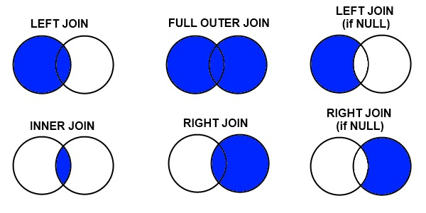

Types of joins

# More on Immutability

## Big data is immutable

One of the key characteristics of data processing is that data is never modified in place. Instead, we apply operations that create new versions of the data, without modifying the original version.

*Immutability* is a general concept that expands in much of the data processing stack.

## Immutability across the stack

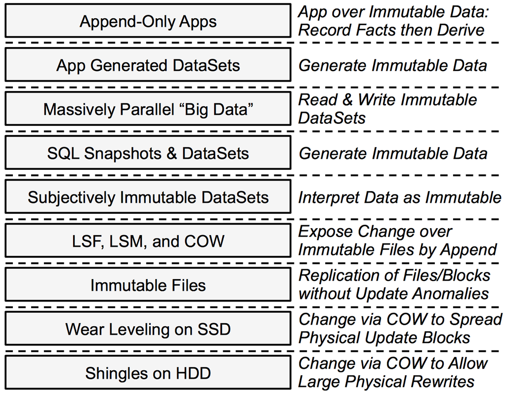

Immutability

Image from Helland in ref [1]

## Copy-On-Write (COW)

*Copy-On-Write* is a general technique that allows us to share memory for read-only access across processes and deal with writes only if/when they are performed by copying the modified resource in a private version.

COW is the basis for many operating system mechanisms, such as process creation (forking), while many new filesystems (e.g. BTRFS, ZFS) use it as their storage format.

COW enables systems with multiple readers and few writers to efficiently share resources.

## Immutable data structures

*Immutable* or *persistent* data structures always preserve the previous version of themselves when they are modified [2].

With immutable data structures, we can:

- Avoid locking while processing them, so we can process items in parallel
- Maintain and share old versions of data
- Seamlessly persist the data on disk
- Reason about changes in the data

They come at a cost of increased memory usage (data is never deleted).

## Example: immutable tree

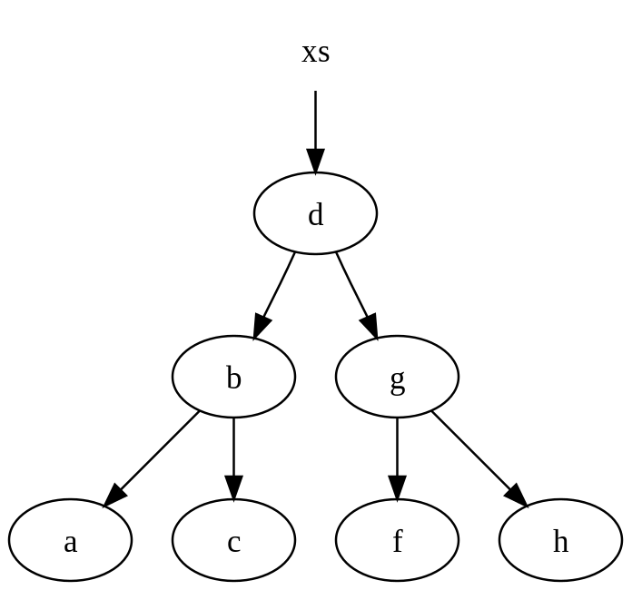

A tree

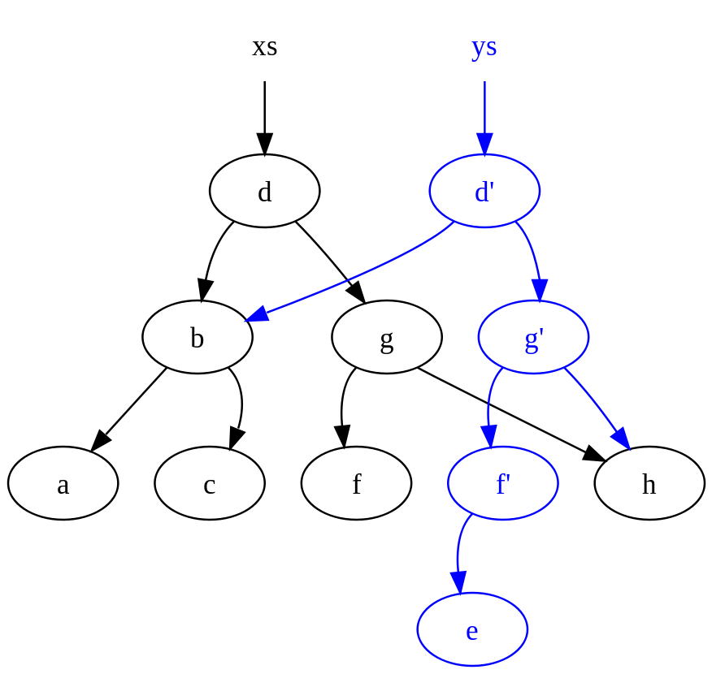

The tree after addition

```scala
val xs = TreeSet[Char]('a', 'b',
                       'c', 'd',
                       'g', 'f',
                       'h')
```

The difference of immutability is apparent only when we try to insert a new node `e`.

```scala
val ys = xs ++ TreeSet[Char]('e')
```

## Data structures in Scala

| ADT | `collection.mutable` | `collection.immutable` |
| --- | --- | --- |
| Array | ArrayBuffer | Vector |
| List | LinkedList | List |
| Map | HashMap | HashMap |
| Set | HashSet | HashSet |
| Queue | SynchronizedQueue | Queue |
| Tree | — | TreeSet |

## Image credits

- Relation image
- [LazyList example](https://www.scala-lang.org/api/2.13.4/scala/collection/immutable/LazyList.html)
- [Transformation image](http://www.exceldashboardtemplates.com/data-transformation-excel-array-solution/)
- [Hashtable image](https://commons.wikimedia.org/wiki/File:Hash_table_3_1_1_0_1_0_0_SP.svg)
- [Join types](https://stackoverflow.com/questions/38549/what-is-the-difference-between-inner-join-and-outer-join)

## Bibliography

[1]

P. Helland, “Immutability changes everything,” *Queue*, vol. 13, no. 9, p. 40, 2015.

[2]

C. Okasaki, *Purely functional data structures*. Cambridge University Press, 1999.

[3]

G. Hutton, “A tutorial on the universality and expressiveness of fold,” *Journal of Functional Programming*, vol. 9, no. 4, pp. 355–372, 1999.

## Copyright

This work is (c) 2017, 2018, 2019, 2020, 2021 - onwards by TU Delft and Georgios Gousios and licensed under the [Creative Commons Attribution-NonCommercial-ShareAlike 4.0 International](http://creativecommons.org/licenses/by-nc-sa/4.0/) license.